# Análise de Impacto do Tarifa-Zero sobre a arrecadação tributária

Projeto de Pesquisa

[Rafael de Acypreste](https://rafaeldeacypreste.github.io/)

Estudante

Thais Carvalho

Orientadora

**Tarifa Zero**

É um modelo de financiamento do transporte público coletivo que é financiado por outras fontes de receita, como impostos, taxas e pedágios, em vez de tarifas pagas pelos(as) passageiros(as).

[figure not shown]

[108 municípios em maio de 2024](https://x.com/_danielsantini/status/1790749556650528832)

[figure not shown]

Formosa-GO (2021)

[figure not shown]

Luziânia-GO (2023)

[figure not shown]

## Motivação

- Avaliação do Tarifa Zero: avaliação das experiências nacionais de Carolina Piazza (2017);
- Impacto na arrecadação: trata-se de uma política que pode ser custosa ao Município; e
- Avaliação causal: como não é possível fazer experimentos, é necessário utilizar métodos de avaliação causal para estudos observacionais.

## Objetivos

- Objetivo geral: Avaliar o impacto da política de Tarifa-Zero na arrecadação tributária municipal (ISS e outros).
- Objetivos específicos:

  1- Organizar o banco de dados de variáveis relacionadas a políticas de transporte;

  2- Identificar o modelo causal mais adequado para avaliar as implicações da Tarifa-Zero na arrecadação tributária municipal; e

  3- Comparar os municípios que adotaram o Tarifa-Zero, estabelecendo municípios que podem funcionar como contrafactual.

# Metodologia

## Inferência causal

**O problema da inferência causal: contrafactual**

O que teria acontecido ao Município se não tivesse implementado a Tarifa-Zero?

Alternativas: Angrist and Pischke (2009), Pearl and Mackenzie (2018), Callaway and Sant’Anna (2021), Roth et al. (2023)

Efeito médio do tratamento nos tratados (ETT):
$$\begin{equation}
\label{eq-counterfactual}
\tau_2 = \mathbb{E}[Y_{i,2}(1) - Y_{i,2}(0) | D_{i,2} = 1]
\end{equation}$$

## Viés de seleção e variáveis confundidoras

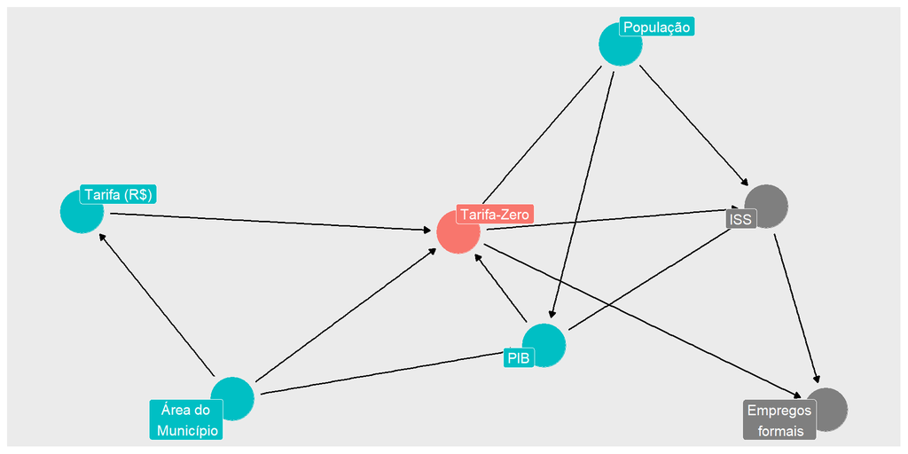

## Variáveis de interesse (fontes)

- Municípios que adotaram o Tarifa-Zero (Santini 2024);
- Arrecadação tributária municipal (IPEA);
- Variáveis demográficas: população e tamanho dos municípios (IBGE);
- Frota veicular (Ministério dos Transportes);
- Trabalho formal (Ministério do Trabalho e Emprego); e
- Mortalidade e morbidade no trânsito (Ministério da Saúde).

## Diferenças-em-Diferenças (Diff-in-Diff)

Consiste em tomar a diferença entre a média do tratamento e do controle antes e depois da implementação da política e, depois, subtrair essas diferenças.

[figure not shown]

$$\begin{equation} \label{eq-did-estimator}
\begin{split}
\tau_2 & = \mathbb{E}[Y_{i,2}(1) - Y_{i,2}(0) | D_{i,2} = 1] \\
& = \mathbb{E}[Y_{i,2} \color{#FBFF0A}{-} Y_{i,1}| \boldsymbol{X}, D_{i,2} = 1] \color{#FBFF0A}{-} \mathbb{E}[Y_{i,2} \color{#FBFF0A}{-} Y_{i,1} | \boldsymbol{X}, D_{i,2} = 0]
\end{split}
\end{equation}$$

## Resultados parciais

[figure not shown]

## Cronograma para 2/2024

| Atividades | Jul | Ago | Set | Out | Nov |
| --- | --- | --- | --- | --- | --- |
| Estimativas dos modelos | X | X | X |  |  |
| Análise de sensitividade |  | X | X | X |  |
| Comparação com outras análises de impacto |  |  | X | X |  |
| Seção de metodologia |  | X | X |  |  |
| Seção de resultados e discussões |  |  | X | X |  |
| Publicação do modelo no Github |  |  |  | X |  |
| Apresentação do trabalho |  |  |  |  | X |

# Referências

Angrist, Joshua D., and Jörn-Steffen Pischke. 2009. *Mostly Harmless Econometrics: An Empiricist’s Companion*. Princeton University Press. http://www.jstor.org/stable/j.ctvcm4j72.

Callaway, Brantly, and Pedro H. C. Sant’Anna. 2021. “Difference-in-Differences with Multiple Time Periods.” *Journal of Econometrics* 225 (2): 200–230. https://doi.org/https://doi.org/10.1016/j.jeconom.2020.12.001.

Pearl, Judea, and Dana Mackenzie. 2018. *The Book of Why: The New Science of Cause and Effect*. Basic Books.

Piazza, Carolina Kowalski. 2017. “Avaliação Do Impacto Econômico Da Gratuidade No Transporte Coletivo (Monografia de Conclusão de Curso).” PhD thesis, University of Santa Catarina. https://repositorio.ufsc.br/handle/123456789/178734.

Roth, Jonathan, Pedro H. C. Sant’Anna, Alyssa Bilinski, and John Poe. 2023. “What’s Trending in Difference-in-Differences? A Synthesis of the Recent Econometrics Literature.” *Journal of Econometrics* 235 (2): 2218–44. https://doi.org/10.1016/j.jeconom.2023.03.008.

Santini, Daniel. 2024. “Brazilian municipalities with full Fare-Free Public Transport policies - updated March 2024.” Version V1. Harvard Dataverse. https://doi.org/10.7910/DVN/Z927PD.